# EPSY 5200: Programming for Social Science Researchers

## Assignment 11

### Due Tuesday, December 1 by 2:30pm

#### Problem 0

If you've made it to this document, you likely already did Problem 0 from the readme. But just in case, here it is again!

a) Let's watch some videos! I recommend all the videos in this series (for future learning), but we will just focus on two now. Watch the first half of this video (https://www.youtube.com/watch?v=_NrSWLQsDL4&list=PLRqwX-V7Uu6ZF9C0YMKuns9sLDzK6zoiV&index=3) -- just the part about forking, you can ignore pull requests! Then watch this video: https://www.youtube.com/watch?v=yXT1ElMEkW8&list=PLRqwX-V7Uu6ZF9C0YMKuns9sLDzK6zoiV&index=6 (you don't have to do the terminal git commands, you can use the clone strategy we used in class)

b) Using what you learned in 0a, **fork** my GitHub repository (remote repo) to your own account, then **clone** to your hard drive (local repo) using GitKraken (or use the command-line if you want the extra challenge). After finishing EACH problem below, make sure to STAGE and COMMIT with a comment (e.g., "Just finished Part 1! Git is fun!" or whatever). Then PUSH back to GitHub.

###### Note on privacy!

By default, GitHub repos are public (promoting open source sharing of code), but of course you are more than welcome to make your code for this assignment private, as is your right! Unfortunately, it's a little bit complicated because GitKraken recently made a change that the free version of their software doesn't allow for private repo access, and you need the paid version. So here are 3 ways to do this privately:

1) GitKraken partners with GitHub to provide a free pack of resources (including the pro version of GitKraken) for *students*. That's you! So you can sign up here *only if you want to do this*: https://education.github.com/pack?utm_source=github+gitkraken

2) Just keep your GitHub repo public while you're working on this project. Use free GitKraken. Then switch the GitHub repo to Private only when you're done using GitKraken to push to GitHub.

3) Keep the repo private and use the terminal git commands in the YouTube video for Problem 0a.

To make the repo private: On your GitHub repo, go to Settings > Manage Access > Manage (under Public Repository) > Change Visibility. Then add me (jkbye) as a 'collaborator' so I can see it: Settings > Manage Access > Invite a Collaborator (green button) > add 'jkbye'.

#### Problem 1

Now let's get to Jupyter!

a) Import any helpful libraries in this Jupyter Notebook.

b) Load the *MA_Public_Schools_2017.csv* file as a pandas data frame. Note: these data are from Kaggle: https://www.kaggle.com/ndalziel/massachusetts-public-schools-data and I have already removed a lot of columns.

c) Adapt the example code in the chunk below to replace all spaces in column names with underscores. This is good practice in order to not cause problems with functions that don't allow spaces in variable names (e.g., **smf.ols**).

d) Adapt the code from 1c to replace "%" sign with "Perc", because it is also good practice not to start column names with symbols.

e) Find the descriptives for numeric columns.

f) Commit your changes and push to GitHub!

```python
# Problem 1 code here (can split into multiple code chunks if you want)
import pandas as pd

school_data = pd.read_csv('MA_Public_Schools_2017.csv')
print(school_data)

# starter code for 1c -- replace school_data w/ your dataframe name
school_data.columns = school_data.columns.str.replace(' ', '_') # notice this replaces the 1st argument w/ the 2nd
print(school_data.columns)

# replace % with Perc
school_data.columns = school_data.columns.str.replace('%','Perc')
print(school_data.columns)


# subset columns with numeric data
num_school_data = (school_data[['PK_Enrollment','K_Enrollment',
       '1_Enrollment', '2_Enrollment', '3_Enrollment', '4_Enrollment',
       '5_Enrollment', '6_Enrollment', '7_Enrollment', '8_Enrollment',
       '9_Enrollment', '10_Enrollment', '11_Enrollment', '12_Enrollment',
       'SP_Enrollment', 'Perc_First_Language_Not_English',
       'Perc_English_Language_Learner', 'Perc_Students_With_Disabilities',
       'Perc_High_Needs', 'Perc_Economically_Disadvantaged',
       'Perc_African_American', 'Perc_Asian', 'Perc_Hispanic', 'Perc_White',
       'Perc_Native_American', 'Perc_Native_Hawaiian,_Pacific_Islander',
       'Perc_Multi-Race,_Non-Hispanic', 'Perc_Males', 'Perc_Females',
       'Average_Class_Size', 'Number_of_Students', 'Salary_Totals',
       'Average_Salary', 'FTE_Count', 'In-District_Expenditures',
       'Total_In-district_FTEs', 'Average_In-District_Expenditures_per_Pupil',
       'Total_Expenditures', 'Total_Pupil_FTEs',
       'Average_Expenditures_per_Pupil']])
print(num_school_data)

# descriptive statistics for numeric data
desc_school_data = (num_school_data).describe().transpose()
print(desc_school_data)

#finished problem 1
```

```
      School Code                                        School Name  \
0           10505                                      Abington High
1           10003                     Beaver Brook Elementary School
2           10002                           Center Elementary School
3           10405                               Frolio Middle School
4           10015                        Woodsdale Elementary School
...           ...                                                ...
1856     35060505     Pioneer Charter School of Science II (PCSS-II)
1857     35100205             Springfield Preparatory Charter School
1858     39020900  TEC Connections Academy Commonwealth Virtual S...
1859     35050405            UP Academy Charter School of Dorchester
1860     35120305           UP Academy Charter School of Springfield

         School Type          Town State  \
0      Public School      Abington    MA
1      Public School      Abington    MA
2      Public School      Abington    MA
3      Public School      Abington    MA
4      Public School      Abington    MA
...              ...           ...   ...
1856  Charter School        Saugus    MA
1857  Charter School   Springfield    MA
1858   Public School  East Walpole    MA
1859  Charter School        Boston    MA
1860  Charter School        Boston    MA

                                      Grade  \
0                               09,10,11,12
1                               01,02,03,04
2                                      PK,K
3                                     07,08
4                                     05,06
...                                     ...
1856                      07,08,09,10,11,12
1857                                K,01,02
1858  K,01,02,03,04,05,06,07,08,09,10,11,12
1859           PK,K,01,02,03,04,05,06,07,08
1860                               06,07,08

                                          District Name  District Code  \
```

[output cut: 329 more lines]

```
Perc_Native_Hawaiian,_Pacific_Islander      1.000000e-01  6.100000e+00
Perc_Multi-Race,_Non-Hispanic               4.775000e+00  1.740000e+01
Perc_Males                                  5.360000e+01  1.000000e+02
Perc_Females                                5.060000e+01  7.600000e+01
Average_Class_Size                          2.080000e+01  4.110000e+01
Number_of_Students                          6.345000e+02  4.327000e+03
Salary_Totals                               4.808571e+07  3.838662e+08
Average_Salary                              7.825600e+04  1.007310e+05
FTE_Count                                   6.270000e+02  4.323000e+03
In-District_Expenditures                    1.287478e+08  1.093104e+09
Total_In-district_FTEs                      7.700400e+03  5.685880e+04
Average_In-District_Expenditures_per_Pupil  1.547808e+04  3.878085e+04
Total_Expenditures                          1.335444e+08  1.269580e+09
Total_Pupil_FTEs                            8.378900e+03  6.596460e+04
Average_Expenditures_per_Pupil              1.590029e+04  3.050505e+04
```

#### Problem 2

a) Remove the District Code column.

b) Create a new column called "TOTAL_Enrollment" that is the sum of all columns that end in "Enrollment".

c) Compute the mean of "TOTAL_Enrollment" for each District. (Hint: groupby)

d) Commit your changes and push to GitHub!

```python
# Problem 2 code here (can split into multiple code chunks if you want)
print(school_data.columns)

# remove district code column
school_data2 = school_data.drop(['District_Code'], axis = 1)

# just checking to make sure the column was removed
print(school_data2.columns)
```

```
Index(['School_Code', 'School_Name', 'School_Type', 'Town', 'State', 'Grade',
       'District_Name', 'District_Code', 'PK_Enrollment', 'K_Enrollment',
       '1_Enrollment', '2_Enrollment', '3_Enrollment', '4_Enrollment',
       '5_Enrollment', '6_Enrollment', '7_Enrollment', '8_Enrollment',
       '9_Enrollment', '10_Enrollment', '11_Enrollment', '12_Enrollment',
       'SP_Enrollment', 'Perc_First_Language_Not_English',
       'Perc_English_Language_Learner', 'Perc_Students_With_Disabilities',
       'Perc_High_Needs', 'Perc_Economically_Disadvantaged',
       'Perc_African_American', 'Perc_Asian', 'Perc_Hispanic', 'Perc_White',
       'Perc_Native_American', 'Perc_Native_Hawaiian,_Pacific_Islander',
       'Perc_Multi-Race,_Non-Hispanic', 'Perc_Males', 'Perc_Females',
       'Average_Class_Size', 'Number_of_Students', 'Salary_Totals',
       'Average_Salary', 'FTE_Count', 'In-District_Expenditures',
       'Total_In-district_FTEs', 'Average_In-District_Expenditures_per_Pupil',
       'Total_Expenditures', 'Total_Pupil_FTEs',
       'Average_Expenditures_per_Pupil'],
      dtype='object')
Index(['School_Code', 'School_Name', 'School_Type', 'Town', 'State', 'Grade',
       'District_Name', 'PK_Enrollment', 'K_Enrollment', '1_Enrollment',
       '2_Enrollment', '3_Enrollment', '4_Enrollment', '5_Enrollment',
       '6_Enrollment', '7_Enrollment', '8_Enrollment', '9_Enrollment',
       '10_Enrollment', '11_Enrollment', '12_Enrollment', 'SP_Enrollment',
       'Perc_First_Language_Not_English', 'Perc_English_Language_Learner',
       'Perc_Students_With_Disabilities', 'Perc_High_Needs',
       'Perc_Economically_Disadvantaged', 'Perc_African_American',
       'Perc_Asian', 'Perc_Hispanic', 'Perc_White', 'Perc_Native_American',
       'Perc_Native_Hawaiian,_Pacific_Islander',
       'Perc_Multi-Race,_Non-Hispanic', 'Perc_Males', 'Perc_Females',
       'Average_Class_Size', 'Number_of_Students', 'Salary_Totals',
       'Average_Salary', 'FTE_Count', 'In-District_Expenditures',
       'Total_In-district_FTEs', 'Average_In-District_Expenditures_per_Pupil',
       'Total_Expenditures', 'Total_Pupil_FTEs',
       'Average_Expenditures_per_Pupil'],
      dtype='object')
```

```python
#Problem 2 cont.

# sum up all the enrollment numbers for all grades for each school
school_data2['Total_Enrollment'] = school_data.iloc[:, 7:21].sum(axis=1)
# I started out doing this school_data['PK_Enrollment'] + school_data['K_Enrollment'] + ...
# but I remembered iloc from a few weeks ago and bashed through this until I got things in
# the right order and it worked!

print(school_data2.columns)
print(school_data2.Total_Enrollment) # to check against Excel spreadsheet totals

# compute mean enrollment of each school district
print(school_data2.groupby('District_Name').mean()['Total_Enrollment'])
```

```
Index(['School_Code', 'School_Name', 'School_Type', 'Town', 'State', 'Grade',
       'District_Name', 'PK_Enrollment', 'K_Enrollment', '1_Enrollment',
       '2_Enrollment', '3_Enrollment', '4_Enrollment', '5_Enrollment',
       '6_Enrollment', '7_Enrollment', '8_Enrollment', '9_Enrollment',
       '10_Enrollment', '11_Enrollment', '12_Enrollment', 'SP_Enrollment',
       'Perc_First_Language_Not_English', 'Perc_English_Language_Learner',
       'Perc_Students_With_Disabilities', 'Perc_High_Needs',
       'Perc_Economically_Disadvantaged', 'Perc_African_American',
       'Perc_Asian', 'Perc_Hispanic', 'Perc_White', 'Perc_Native_American',
       'Perc_Native_Hawaiian,_Pacific_Islander',
       'Perc_Multi-Race,_Non-Hispanic', 'Perc_Males', 'Perc_Females',
       'Average_Class_Size', 'Number_of_Students', 'Salary_Totals',
       'Average_Salary', 'FTE_Count', 'In-District_Expenditures',
       'Total_In-district_FTEs', 'Average_In-District_Expenditures_per_Pupil',
       'Total_Expenditures', 'Total_Pupil_FTEs',
       'Average_Expenditures_per_Pupil', 'Total_Enrollment'],
      dtype='object')
0          10356
1          10580
2          10203
3          10328
4          10353
          ...
1856    35060310
1857    35100163
1858    39021002
1859    35050744
1860    35120000
Name: Total_Enrollment, Length: 1861, dtype: int64
District_Name
Abby Kelley Foster Charter Public (District)            4.451344e+06
Abington                                                1.036400e+04
Academy Of the Pacific Rim Charter Public (District)    4.120478e+06
Acton-Boxborough                                        6.000569e+06
Acushnet                                                3.047750e+04
                                                            ...
Winthrop                                                3.460462e+06
Woburn                                                  3.470392e+06
Worcester                                               3.480529e+06
Worthington                                             3.490060e+06
Wrentham                                                3.500516e+06
Name: Total_Enrollment, Length: 410, dtype: float64
```

#### Problem 3

a) Visualize each bivariate relationship among Average_Class_Size, Average_Salary, Perc_Economically_Disadvantaged, and Perc_English_Language_Learner. Use the Seaborn function **pairplot**. The argument to `pairplot` should be `school_data[['Average_Class_Size', 'Average_Salary', 'Perc_Economically_Disadvantaged', 'Perc_English_Language_Learner']]`, which will just pull those columns out from the full data frame.

b) Describe what you see from the plots.

c) Based on your observations from 3b, and as a completely post-hoc, exploratory analysis, choose one of the 4 measures from 3a to be an outcome variable, and a second measure to be a predictor variable. Then run a linear regression, print the *summary*, and write a sentence interpreting the results (does not need to be detailed, just practice retrieving the relevant info on predictor significance, etc.)

d) Commit your changes and push to GitHub!

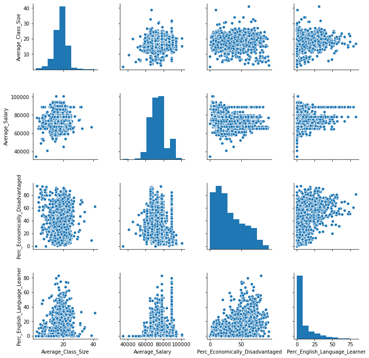

```python
# Problem 3 code here (can split into multiple code chunks if you want)

import seaborn as sns
import statsmodels.formula.api as smf

sns.pairplot(
    school_data2[['Average_Class_Size', 'Average_Salary',
                 'Perc_Economically_Disadvantaged', 'Perc_English_Language_Learner']])
```

These plots are a little hard for me to interpret. I think schools included largely have class sizes around 20 students, most of the teachers have a salary at or above $60k, the percentage of students who are economically disadvantaged seems relatively low and there aren't that many English learners.

OLS Regression Results

| Dep. Variable: | Average_Class_Size | R-squared: | 0.009 |
| --- | --- | --- | --- |
| Model: | OLS | Adj. R-squared: | 0.008 |
| Method: | Least Squares | F-statistic: | 15.15 |
| Date: | Wed, 02 Dec 2020 | Prob (F-statistic): | 0.000103 |
| Time: | 17:29:02 | Log-Likelihood: | -4816.9 |
| No. Observations: | 1743 | AIC: | 9638. |
| Df Residuals: | 1741 | BIC: | 9649. |
| Df Model: | 1 |  |  |
| Covariance Type: | nonrobust |  |  |

|  | coef | std err | t | P>\|t\| | [0.025 | 0.975] |
| --- | --- | --- | --- | --- | --- | --- |
| Intercept | 14.9223 | 0.855 | 17.461 | 0.000 | 13.246 | 16.598 |
| Average_Salary | 4.465e-05 | 1.15e-05 | 3.893 | 0.000 | 2.22e-05 | 6.71e-05 |

| Omnibus: | 185.777 | Durbin-Watson: | 1.758 |
| --- | --- | --- | --- |
| Prob(Omnibus): | 0.000 | Jarque-Bera (JB): | 422.137 |
| Skew: | -0.632 | Prob(JB): | 2.16e-92 |
| Kurtosis: | 5.053 | Cond. No. | 6.92e+05 |

Warnings:  
[1] Standard Errors assume that the covariance matrix of the errors is correctly specified.  
[2] The condition number is large, 6.92e+05. This might indicate that there are  
strong multicollinearity or other numerical problems.

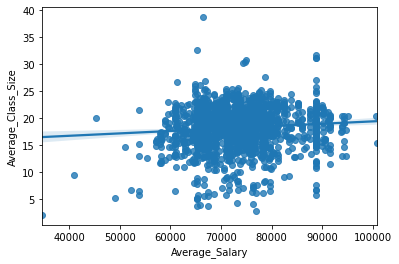

```python
# post hoc exploratory analysis looking at relationship between teacher salary and class size
sns.regplot(school_data2.Average_Salary , school_data2.Average_Class_Size)

lm = smf.ols(formula = "Average_Class_Size ~ Average_Salary", data = school_data2).fit()
lm.summary()
```

The R-squared value is low and the model only accounts for 0.9% of the variance in the dependent variable (class size). It looks like teacher salary can predict class size--there is a significant positive relationship between salary and class size. I was assuming that teachers with more seniority would make more money and be able to have smaller class sizes.

Problem 3 done!

#### Problem 4

a) Create a new linear regression model that takes the model from 3c and adds both of the remaining variables from 3a as additional predictor variables. To do this, the formula interface would look like `"outcome_name ~ predictor1_name + predictor2_name + predictor3_name"`

b) Print the summary from 4a, and write a short interpretation of the results, especially comparing it to Problem 3c.

d) Commit your changes and push to GitHub!

```python
# Problem 4 code here (can split into multiple code chunks if you want)

lm2 = smf.ols(formula = "Average_Class_Size ~ Average_Salary + Perc_English_Language_Learner + Perc_Economically_Disadvantaged", data = school_data2).fit()

lm2.summary()
```

OLS Regression Results

| Dep. Variable: | Average_Class_Size | R-squared: | 0.063 |
| --- | --- | --- | --- |
| Model: | OLS | Adj. R-squared: | 0.061 |
| Method: | Least Squares | F-statistic: | 38.75 |
| Date: | Wed, 02 Dec 2020 | Prob (F-statistic): | 3.08e-24 |
| Time: | 17:29:08 | Log-Likelihood: | -4768.1 |
| No. Observations: | 1743 | AIC: | 9544. |
| Df Residuals: | 1739 | BIC: | 9566. |
| Df Model: | 3 |  |  |
| Covariance Type: | nonrobust |  |  |

|  | coef | std err | t | P>\|t\| | [0.025 | 0.975] |
| --- | --- | --- | --- | --- | --- | --- |
| Intercept | 19.6251 | 0.957 | 20.518 | 0.000 | 17.749 | 21.501 |
| Average_Salary | -7.414e-06 | 1.25e-05 | -0.594 | 0.552 | -3.19e-05 | 1.71e-05 |
| Perc_English_Language_Learner | 0.0825 | 0.010 | 8.587 | 0.000 | 0.064 | 0.101 |
| Perc_Economically_Disadvantaged | -0.0518 | 0.005 | -9.590 | 0.000 | -0.062 | -0.041 |

| Omnibus: | 104.914 | Durbin-Watson: | 1.783 |
| --- | --- | --- | --- |
| Prob(Omnibus): | 0.000 | Jarque-Bera (JB): | 262.181 |
| Skew: | -0.336 | Prob(JB): | 1.17e-57 |
| Kurtosis: | 4.777 | Cond. No. | 7.97e+05 |

Warnings:  
[1] Standard Errors assume that the covariance matrix of the errors is correctly specified.  
[2] The condition number is large, 7.97e+05. This might indicate that there are  
strong multicollinearity or other numerical problems.

The predictors now account for 6% of the variance. There are significant relationships between English language learner percentage and low SES and class size. Teacher salary no longer has a significant relationship with class size with the addition of these predictors.

Problem 4 done!

#### Problem 5

a) Adapt your **pairplot** code from 3a to add the following argument: `hue="School_Type"`

b) Describe what changes in the pairplots, and what it represents.

c) Commit your changes and push to GitHub!

[output not shown]

[output cut: 9 more lines]

[output not shown]

[figure not shown]

```python
# Problem 5 code here (can split into multiple code chunks if you want)

sns.pairplot(
    school_data2[['Average_Class_Size', 'Average_Salary','Perc_Economically_Disadvantaged',
                  'Perc_English_Language_Learner']] , hue='School_Type')

# I want to submit this homework so I'm just leaving this as not working, I haven't figure out why.
```

Problem 5 done, more or less

#### Problem 6

a) Save this Jupyter notebook as an HTML file (File > Download As > HTML) into your local repository (this folder). By default, Jupyter may put your HTML file in your default Downloads folder (wherever that is) -- if that happens, just manually move the file into this repo folder.

b) Stage, commit, and push all changes to your GitHub repository.

c) Submit a link to your repository as your submission for the assignment on Canvas. Remember the note from Problem 0: you can keep your repo private and add me as a collaborator.